# 718 policy plots

Ernesto Carrella

6/30/2020

# 1 Paper

# 2 Introduction

- talk about the price shock

# 3 Methods

## 3.1 Model

- 2 ports, 3 fleets, 3 species model
- Start the fishery “ab novo”
- max of 40 years
- species follow boxcar methods, no prey-predator interaction
- Length structure, daily step
- Life parameters are drawn from FishLife on the assumption that $L_{\infty}$ is estimated correctly
- Beverton holt with wide steepness prior (0.6~0.95) and virgin recruits, $\Phi$ wide and centered around cMSY output with sea around us data
- 5x5 geography with longliner population coming out of Probollingo
- some cells contain only Atrobucca others only the other two species
- Atrobucca starts out as worthless, the other species sell for random price of between 30,000 and 60,000 IDR per kg.
- Because fleet also catch other minor species these are not simulated in the biological layer but they are caught at fixed proportion with the rest of the fish and sold also for between 30,000 and 60,000 IDR per kg
- Longiners use logistic selectivity
- Gillnetters use dome-shaped curve from DLM toolkit
- Each fleet has different parameters for each of the species
- Gillnetters are assumed to have 0 Atrobucca catchability
- The contribution to catches by other fleets is simulated as a yearly, fixed fishing mortality F
- There is entry and exit proportional to profits for each fleet separately
- Boats that make negative revenue - variable cost can become seasonal and then retire
- We simulate length-based SPR collection following IFish formulas and assumed life history parameters (which may differ from the simulated ones we draw from FishLife)
- We simulate also the same level of coverage: SPR is computed by observing 16 longliners from Probollingo, 16 longliners from Dobo and 4 gillnetters
- weaknesses
  - no australia boost
  - no nano boats
  - did not assume smaller boats may be able to join the fishery

## 3.2 Rejection sampling evidence

- We have many parameters we are unsure about
- We only have limited information we can condition on
- Try to capture the important story of this fishery
- The fishery was primarily a L.malabaricus fishery that suddenly faced a price shock making A. brevis very expensive
- Within two years A. brevis SPR crashed to below 10% (from approximately 100% two years ago).
- In the same time frame SPR of malabaricus remained unchanged and laticaudis SPR looks healthy
- We are going to condition on this story by using rejection filtering
- We randomize parameters by drawing from priors and run simulations
- We also simulate a price shock to Atrobucca Brevis where the price increases to 80,000 IDR per kg in 718 and for longliners coming from Java the price increases to 200,0000 IDR per kg
- We reject all simulations that do not pass 11 filters within 2-5 years of the price shock.

| Variable | Target value |
| --- | --- |
| SPR A. brevis | <10% |
| SPR L. malabaricus | <10% |
| SPR L. laticaudis | >40% |
| Landings A. brevis | 600t - 2000t |
| Landings L. malabaricus | 2500t - 5000t |
| Landings L. laticaudis | 400t - 2000t |
| Gillnetters | always active |
| Local longliners | always active |
| Long-range longliners | active after shock |
| 2 year change SPR A. brevis | drop by at least 40% |
| 2 year change SPR L. malabaricus | change by less than 10% |

- with the set of accepted fisheries we perform two operations
  - apply a policy to all the fisheries in the set to check its overall effect
  - test the value of the filters by looking at the fisheries we would have accepted otherwise

# 4 Results

## 4.1 Status and value of information

After rejection sampling we isolate 141 fisheries that clear all evidence. The accepted fisheries correctly simulate a drop in SPR for A.brevis, high SPR for L. lauticadus and low steady SPR for L.malabaricus. Figure 4.1 displays observed SPRs and their confidence intervals .

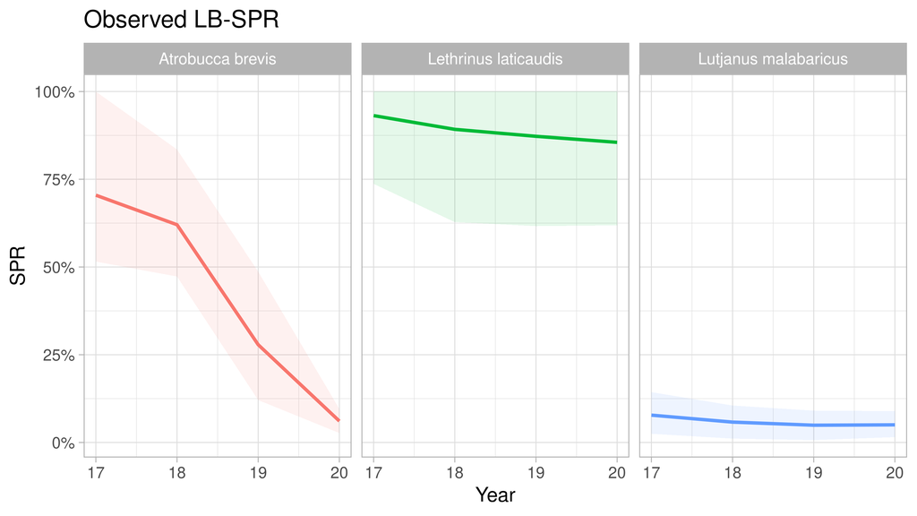

Figure 4.1: The simulated SPR time series observed in the accepted fisheries for the past four years. The bolded line is the average of all runs, the shaded area around it represents the 10th and 90th percentile interval. The simulated SPR here is computed by observing yearly catch at length distribution following 16 long-distance longliners, 16 local longliners and 4 gillnetters, as the original data computed it.

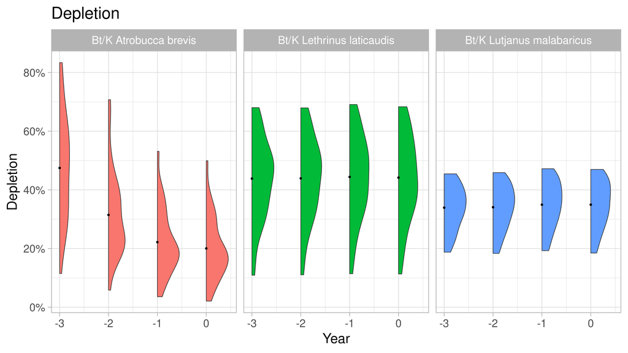

Figure 4.2: Yearly distribution for $\frac{B_t}{K}$ for the three simulated species across all accepted fisheries. While A. brevis clearly deteriorates, following the trend in its SPR, the stock for the other two species is stable. Particularly for L. malabaricus, the distribution is concentrated around healthy levels of depletion even though its SPR is consistently recorded to be very low.

The core issue with assessing the status of L. malabaricus is that we have conflicting evidence. On the one hand we observe SPR below 20% for at least 4 years. This implies at least two generations have now been severely overfished before they could spawn. On the other hand we did not observe either a drop in landings nor CPUE. Moreover the stock can still sustain both the landings of long-range longliners (which are expensive) and gillnetters (who target primarily malabaricus and whose selectivity requires enough large fish to stay profitable).

Rejection sampling solves this impasse by exploiting the sensitivity of length-based SPR approximation to small errors in $\frac M K$ ratio assumptions. As figure 4.3 shows the the assumption $\frac M K \approx 0.85$ that we use to compute SPR from catch-at-length distributions is low compared to both Fishlife prior and the rejection-sampling posterior. By having a “true” $\frac M K$ higher than what is used to compute SPR, our calibration have it “both ways”: low observed SPR but consistent catches for all the fleets.

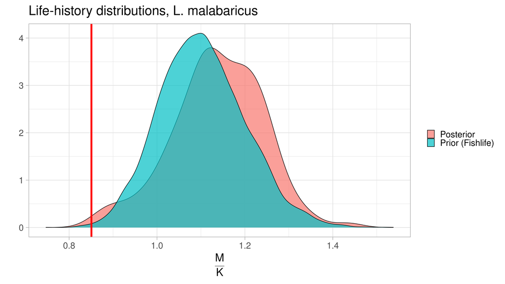

Figure 4.3: Density of prior and posterior for the $\frac M K$ ratio of L. malabaricus. The prior is obtained by drawing at random from Fishlife guessed distributions of $M$ and $K$ after conditioning for $l_{\infty}$ to be equal to what is assumed by TNC. The posterior is the distribution of $\frac M K$ present in the accepted fisheries. The bold red line is the $\frac M K$ assumed when computing length-based SPR

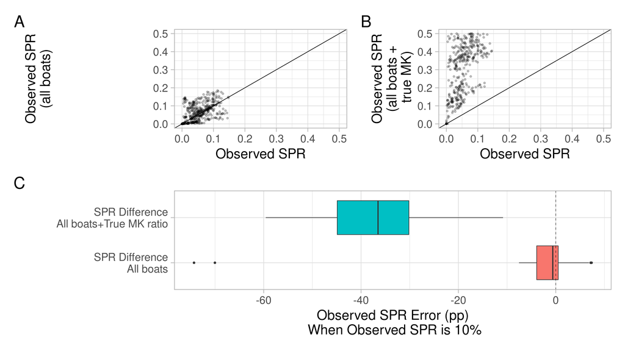

Figure 4.4: Figure A shows the scatterplot of SPR as observed by sampling yearly 16 long-distance longliners, 16 local longliners and 4 gillnetters versus what is obtained by the same formula when sampling the whole fleet. Figure B shows the same comparison but this time together with sampling the whole fleet the SPR formula is also updated by using the true life-history parameters. Figure C shows the distribution of differences between observed SPR and their alternative observations. These distributions only involve the subset of observations where the original SPR is between 9/% and 11/% (as is the actual data for 2019).

## 4.2 Policy

### 4.2.1 Business as usual

Without any new policy put in place we expect A. brevis to deplete further. In the short run, boats (some who just joined due to the price shock) will substitute missing A. brevis landings by targeting more malabaricus; in the long run effort will decrease as some boats will leave the fishery.

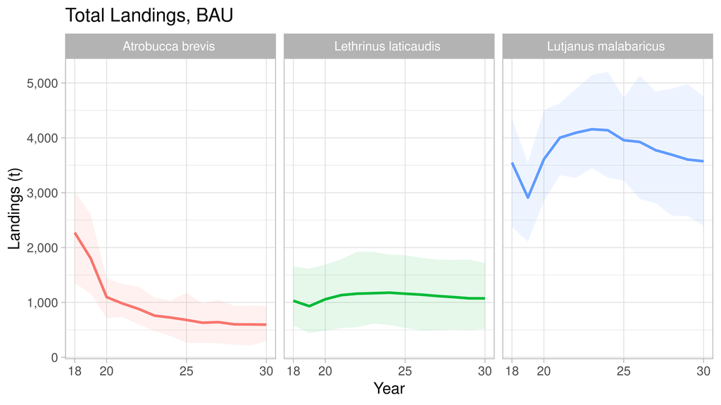

Figure 4.5: Time series of simulated landings for the three major species for the next ten years, assuming no new policy is in place. Landings of A. brevis will keep decreasing from their peak, substituted in the short run by more L. malabaricus. The bolded line is the average of all runs, the shaded area around it represents the 10th and 90th percentile interval.

While in absolute terms A. brevis landings will decrease, the species will remain an important economic driver for the fishery. Even by 2030 our median prediction is that A. brevis will represent only 8% of the landings but 25% of the earnings. Figure 4.6 shows the contribution in earnings from each species for our median prediction. Because this source of earnings did not exist until a few years ago we expect the effort to remaing higher than pre-shock levels in the short run.

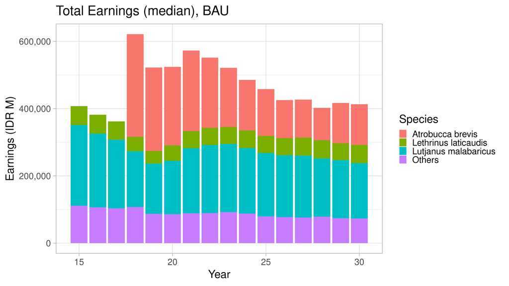

Figure 4.6: The median (across simulations) composition of earnings made from landing each species. By the time calibration ends (2020) the importance of A. brevis in terms of earnings is already on the decline and will continue to do so over the years. However A. brevis will still account for a quarter of earnings by 2030.

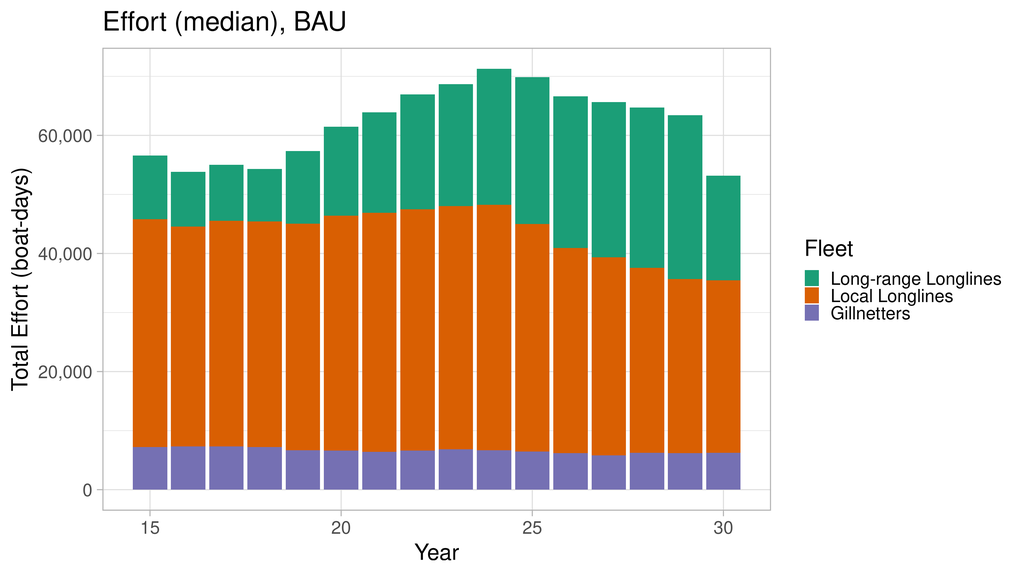

Figure 4.7: The median (across simulations) composition of effort made, in terms of days at sea, for each fleet where no policy is implemented. While for most of the following ten years effort will be above current level, days at sea by long-range longliners will substitute away local 718 ones as they command higher prices for A. brevis.

### 4.2.2 Seasonal closures and fleet reduction

Table 4.1: Median percentage change for selected indicators, simulating all policies on all accepted fisheries.

|  | Total Earnings (M IDR) 5 | Total Earnings (M IDR) 10 | L. malabaricus Landings 5 | L. malabaricus Landings 10 | L. malabaricus Depletion 5 | L. malabaricus Depletion 10 | L. laticaudis Landings 5 | L. laticaudis Landings 10 | L. laticaudis Depletion 5 | L. laticaudis Depletion 10 | Effort (days) 5 | Effort (days) 10 | A. brevis Landings 5 | A. brevis Landings 10 | A. brevis Depletion 5 | A. brevis Depletion 10 |
| --- | --- | --- | --- | --- | --- | --- | --- | --- | --- | --- | --- | --- | --- | --- | --- | --- |
| Business As Usual | -3.4% | -17.5% | 6.7% | -0.4% | -7.3% | -8.3% | 1.6% | 1.0% | -4.2% | -4.3% | 5.3% | 2.9% | -30.7% | -44.3% | -25.6% | -28.2% |
| No Entry | -8.2% | -10.0% | 0.2% | 1.5% | -3.0% | -1.2% | -6.8% | -8.8% | -0.5% | 1.7% | -4.5% | -11.6% | -32.4% | -26.4% | -18.3% | -19.3% |
| 20 Days Closure | -10.1% | -10.7% | -2.1% | 1.8% | 0.9% | 2.1% | -8.5% | -7.0% | 1.8% | 4.1% | -12.8% | -14.6% | -34.3% | -31.5% | -18.3% | -17.9% |
| 50 Days Closure | -12.3% | -8.4% | -9.9% | -1.8% | 5.7% | 10.9% | -13.1% | -9.4% | 5.0% | 7.6% | -20.7% | -21.6% | -23.5% | -30.6% | -5.4% | -5.7% |
| 100 Days Closure | -21.2% | -18.1% | -24.3% | -16.3% | 18.6% | 28.4% | -26.4% | -23.0% | 13.8% | 17.9% | -36.2% | -37.1% | -27.4% | -25.2% | 4.3% | 7.6% |
| 2% Fleet Reduction YOY | -13.1% | -16.6% | -6.1% | -7.9% | -1.7% | 4.5% | -12.6% | -13.1% | 0.3% | 5.3% | -13.2% | -27.3% | -30.1% | -32.7% | -15.3% | -16.4% |
| 4% Fleet Reduction YOY | -15.8% | -23.3% | -9.6% | -19.8% | 2.2% | 13.4% | -14.9% | -25.5% | 1.3% | 8.5% | -23.7% | -38.3% | -28.9% | -33.5% | -15.5% | -11.0% |

Table 4.2: Median value for selected indicators, simulating all policies on all accepted fisheries.

|  | L. malabaricus SPR 5 | L. malabaricus SPR 10 | L. malabaricus Depletion 5 | L. malabaricus Depletion 10 | L. laticaudis SPR 5 | L. laticaudis SPR 10 | L. laticaudis Depletion 5 | L. laticaudis Depletion 10 | A. brevis SPR 5 | A. brevis SPR 10 | A. brevis Depletion 5 | A. brevis Depletion 10 |
| --- | --- | --- | --- | --- | --- | --- | --- | --- | --- | --- | --- | --- |
| Business As Usual | 5.1% | 4.7% | 33.1% | 32.5% | 100.0% | 100.0% | 38.9% | 40.9% | 6.0% | 5.4% | 13.2% | 12.0% |
| No Entry | 5.2% | 4.6% | 34.0% | 34.8% | 100.0% | 100.0% | 41.2% | 44.0% | 7.6% | 7.9% | 15.5% | 14.6% |
| 20 Days Closure | 6.1% | 5.5% | 35.8% | 35.5% | 100.0% | 100.0% | 41.7% | 45.5% | 7.9% | 8.2% | 16.1% | 16.5% |
| 50 Days Closure | 6.5% | 6.1% | 37.4% | 38.0% | 100.0% | 100.0% | 44.0% | 49.5% | 8.9% | 8.3% | 18.0% | 18.2% |
| 100 Days Closure | 5.8% | 7.4% | 42.5% | 45.0% | 100.0% | 100.0% | 48.4% | 52.3% | 9.2% | 11.0% | 20.3% | 21.0% |
| 2% Fleet Reduction YOY | 6.0% | 6.3% | 35.2% | 38.4% | 100.0% | 100.0% | 42.4% | 47.4% | 8.1% | 9.0% | 15.8% | 15.8% |
| 4% Fleet Reduction YOY | 6.3% | 7.6% | 35.8% | 40.4% | 100.0% | 100.0% | 43.2% | 50.3% | 9.3% | 10.8% | 16.0% | 16.8% |

### 4.2.3 Marine Protected Areas

The problem of effort control is that it affects A. brevis the least, given its price. A. brevis however lives at a different depth than the other species, so it is in theory possible to protect it with some additional spatial management. It should be possible then to use a protected area to rebuild A. brevis the way effort control alone cannot.

In this set of simulations we implement a perfectly enforced protected area covering a random proportion between 15% to 50% of the total A. brevis habitat. Three main results emerge. First, the protected area together with ban on new entries, even without any other effort control, is enough to increase $\frac{B_t}{K}$ by, on average, 50% within ten years. Second, target switching is minimal as L. malabaricus and L.lauticaudis stock is not negatively affected by the closure in the long run. Third, the connection between SPR and depletion for A. brevis breaks down. This is because mature fish lives within the MPA while their young spawn is caught by boats as they mature outside of the protected area. The median changes for selected indicators are shown in table 4.3.

Table 4.3: Median percentage change for selected indicators, simulating all protected area policies on all accepted fisheries.

|  | Total Earnings (M IDR) 5 | Total Earnings (M IDR) 10 | L. malabaricus Landings 5 | L. malabaricus Landings 10 | L. malabaricus Depletion 5 | L. malabaricus Depletion 10 | L. laticaudis Landings 5 | L. laticaudis Landings 10 | L. laticaudis Depletion 5 | L. laticaudis Depletion 10 | Effort (days) 5 | Effort (days) 10 | A. brevis Landings 5 | A. brevis Landings 10 | A. brevis Depletion 5 | A. brevis Depletion 10 |
| --- | --- | --- | --- | --- | --- | --- | --- | --- | --- | --- | --- | --- | --- | --- | --- | --- |
| Business As Usual | -3.4% | -17.5% | 6.7% | -0.4% | -7.3% | -8.3% | 1.6% | 1.0% | -4.2% | -4.3% | 5.3% | 2.9% | -30.7% | -44.3% | -25.6% | -28.2% |
| MPA and No Entry | -13.2% | -14.4% | -0.5% | -1.8% | -4.8% | -2.4% | -5.6% | -6.4% | -2.8% | 1.0% | -4.7% | -12.4% | -41.9% | -37.1% | 38.7% | 50.0% |
| MPA and 20 Days Closure | -13.1% | -15.3% | -1.5% | -0.3% | -1.4% | 1.1% | -6.5% | -9.9% | 0.5% | 3.3% | -13.5% | -15.7% | -40.9% | -36.2% | 35.1% | 57.3% |
| MPA and 50 Days Closure | -18.7% | -15.4% | -4.7% | -1.7% | 4.4% | 9.5% | -12.4% | -10.6% | 4.0% | 8.2% | -20.8% | -22.2% | -41.9% | -39.3% | 41.1% | 60.3% |
| MPA and 100 Days Closure | -28.2% | -22.5% | -14.2% | -14.5% | 15.6% | 25.1% | -23.0% | -22.4% | 12.0% | 19.7% | -36.3% | -36.4% | -40.1% | -34.8% | 50.3% | 78.3% |

The stocks of the median fishery will rebuild at a level above $\frac{B_t}{K}>.3$ within 10 years by imposing a protected area and allow no new entries. The median L. malabaricus stock remains at constant levels if the MPA is combined with a 20 days seasonal closure. This we show in table 4.4. Seasonal closures of 50 or 100 days have a strong short-term effect as boats leave the fishery but in the long-run some of the same boats rejoin as stocks improve.

Table 4.4: Median value for selected indicators, simulating all policies on all accepted fisheries.

|  | L. malabaricus SPR 5 | L. malabaricus SPR 10 | L. malabaricus Depletion 5 | L. malabaricus Depletion 10 | L. laticaudis SPR 5 | L. laticaudis SPR 10 | L. laticaudis Depletion 5 | L. laticaudis Depletion 10 | A. brevis SPR 5 | A. brevis SPR 10 | A. brevis Depletion 5 | A. brevis Depletion 10 |
| --- | --- | --- | --- | --- | --- | --- | --- | --- | --- | --- | --- | --- |
| Business As Usual | 5.1% | 4.7% | 33.1% | 32.5% | 100.0% | 100.0% | 38.9% | 40.9% | 6.0% | 5.4% | 13.2% | 12.0% |
| MPA and No Entry | 6.2% | 4.7% | 33.4% | 34.9% | 100.0% | 100.0% | 40.2% | 44.0% | 5.9% | 5.7% | 27.4% | 33.7% |
| MPA and 20 Days Closure | 5.2% | 4.8% | 34.0% | 35.1% | 100.0% | 100.0% | 40.7% | 44.5% | 5.8% | 5.8% | 28.2% | 34.3% |
| MPA and 50 Days Closure | 6.6% | 6.2% | 36.4% | 37.7% | 100.0% | 100.0% | 43.6% | 48.6% | 6.4% | 6.3% | 29.1% | 34.4% |
| MPA and 100 Days Closure | 7.2% | 7.9% | 40.5% | 44.4% | 100.0% | 100.0% | 48.0% | 51.5% | 9.1% | 8.0% | 31.0% | 37.2% |

# 5 Discussion and conclusion